# Simulating COVID-19 interventions with R

Tim Churches

2020-03-21

# Source code for The Conversation article, March 2020

Please read the technical blog posts [here](https://timchurches.github.io/blog/posts/2020-03-10-modelling-the-effects-of-public-health-interventions-on-covid-19-transmission-part-1/) and [here](https://timchurches.github.io/blog/posts/2020-03-18-modelling-the-effects-of-public-health-interventions-on-covid-19-transmission-part-2/) before attempting to use the code below.

## Set-up

```r
for (pkg in c("tidyverse", "magrittr", "lubridate", "knitr",
              "devtools", "DiagrammeR", "EpiModel",
              "parallel", "foreach", "tictoc", "patchwork"))
  if (!requireNamespace(pkg)) install.packages(pkg)
```

```r
knitr::opts_chunk$set(echo = FALSE, cache=TRUE,
                      tidy.opts=list(width.cutoff=60),
                      tidy=TRUE)

library(tidyverse)
library(patchwork)
library(magrittr)
library(lubridate)
library(knitr)
library(tictoc)
suppressMessages(library(EpiModel))
library(DiagrammeR)
library(devtools)
library(parallel)
library(foreach)

tic()
```

## Simulation model compartment diagram

```r
grViz("
digraph SEIQHRF {

  # a 'graph' statement
  graph [overlap = false, fontsize = 10] #, rankdir = LR]

  # several 'node' statements
  node [shape = box,
        fontname = Helvetica]
  S[label='S=Susceptible'];
  E[label='E=Exposed and infected,\nasymptomatic,\npotentially infectious'];
  I[label='I=Infected and infectious'];
  Q[label='Q=(Self-)isolated\n(infectious)'];
  H[label='H=Requires\nhospitalisation'];
  R[label='R=Recovered/immune'];
  F[label='F=Case fatality']

  # several 'edge' statements
  S->E
  I->S[style='dashed']
  E->I
  E->S[style='dashed']
  I->Q
  Q->S[style='dashed']
  I->R
  I->H
  H->F
  H->R
  Q->R
  Q->H
}
")
```

[interactive chart not shown]

# Baseline simulation

## Load EpiModel extensions

```r
source_files <- c("_icm.mod.init.seiqhrf.R", "_icm.mod.status.seiqhrf.R",
    "_icm.mod.vital.seiqhrf.R", "_icm.control.seiqhrf.R", "_icm.utils.seiqhrf.R",
    "_icm.saveout.seiqhrf.R", "_icm.icm.seiqhrf.R")

src_path <- paste0("./_posts/2020-03-18-modelling-the-effects-of-public-health-",
    "interventions-on-covid-19-transmission-part-2/")

gist_url <- "https://gist.github.com/timchurches/92073d0ea75cfbd387f91f7c6e624bd7"

local_source <- FALSE

for (source_file in source_files) {
    if (local_source) {
        source(paste(src_path, source_file, sep = ""))
    } else {
        source_gist(gist_url, filename = source_file)
    }
}
```

## Simulation harness function with baseline defaults

```r
# function to set-up and run the baseline simulations

hc_scaler <- 10 # 1 for 10,000 pop, 10 for 100,000 pop, 100 for 1,000,000 pop

simulate <- function(# control.icm params
                     type = "SEIQHRF",
                     nsteps = 366,
                     nsims = 8,
                     ncores = 4,
                     prog.rand = FALSE,
                     rec.rand = FALSE,
                     fat.rand = TRUE,
                     quar.rand = FALSE,
                     hosp.rand = FALSE,
                     disch.rand = TRUE,
                     infection.FUN = infection.seiqhrf.icm,
                     recovery.FUN = progress.seiqhrf.icm,
                     departures.FUN = departures.seiqhrf.icm,
                     arrivals.FUN = arrivals.icm,
                     get_prev.FUN = get_prev.seiqhrf.icm,
                     # init.icm params
                     s.num = 99970, # 999970
                     e.num=0,
                     i.num = 3, # 30
                     q.num=0,
                     h.num=0,
                     r.num = 0,
                     f.num = 0,
                     # param.icm params
                     inf.prob.e = 0.02,
                     act.rate.e = 10,
                     inf.prob.i = 0.05,
                     act.rate.i = 10,
                     inf.prob.q = 0.02,
                     act.rate.q = 2.5,
                     quar.rate = 1/30,
                     hosp.rate = 1/100,
                     disch.rate = 1/15,
                     prog.rate = 1/10,
                     prog.dist.scale = 5,
                     prog.dist.shape = 1.5,
                     rec.rate = 1/20,
                     rec.dist.scale = 35,
                     rec.dist.shape = 1.5,
                     fat.rate.base = 1/50,
                     hosp.cap = 40*hc_scaler, # 4000 replace red ref line too
                     fat.rate.overcap = 1/25,
                     fat.tcoeff = 0.5,
                     vital = TRUE,
                     a.rate = (10.5/365)/1000,
                     a.prop.e = 0.01,
                     a.prop.i = 0.001,
                     a.prop.q = 0.01,
                     ds.rate = (7/365)/1000,
                     de.rate = (7/365)/1000,
                     di.rate = (7/365)/1000,
                     dq.rate = (7/365)/1000,
                     dh.rate = (20/365)/1000,
                     dr.rate = (7/365)/1000,
                     out="mean"
                    ) {

  control <- control.icm(type = type,
                         nsteps = nsteps,
                         nsims = nsims,
                         ncores = ncores,
                         prog.rand = prog.rand,
                         rec.rand = rec.rand,
                         infection.FUN = infection.FUN,
                         recovery.FUN = recovery.FUN,
                         arrivals.FUN = arrivals.FUN,
                         departures.FUN = departures.FUN,
                         get_prev.FUN = get_prev.FUN)

  init <- init.icm(s.num = s.num,
                   e.num = e.num,
                   i.num = i.num,
                   q.num = q.num,
                   h.num = h.num,
                   r.num = r.num,
                   f.num = f.num)

  param <-  param.icm(inf.prob.e = inf.prob.e,
                      act.rate.e = act.rate.e,
                      inf.prob.i = inf.prob.i,
                      act.rate.i = act.rate.i,
                      inf.prob.q = inf.prob.q,
                      act.rate.q = act.rate.q,
                      quar.rate = quar.rate,
                      hosp.rate = hosp.rate,
                      disch.rate = disch.rate,
                      prog.rate = prog.rate,
                      prog.dist.scale = prog.dist.scale,
                      prog.dist.shape = prog.dist.shape,
                      rec.rate = rec.rate,
                      rec.dist.scale = rec.dist.scale,
                      rec.dist.shape = rec.dist.shape,
                      fat.rate.base = fat.rate.base,
                      hosp.cap = hosp.cap,
                      fat.rate.overcap = fat.rate.overcap,
                      fat.tcoeff = fat.tcoeff,
                      vital = vital,
                      a.rate = a.rate,
                      a.prop.e = a.prop.e,
                      a.prop.i = a.prop.i,
                      a.prop.q = a.prop.q,
                      ds.rate = ds.rate,
                      de.rate = de.rate,
                      di.rate = di.rate,
                      dq.rate = dq.rate,
                      dh.rate = dh.rate,
                      dr.rate = dr.rate)

  sim <- icm.seiqhrf(param, init, control)
  sim_df <- as.data.frame(sim, out=out)

  return(list(sim=sim, df=sim_df))
}
```

# Simulation runs

## Baseline

```r
baseline_sim <- simulate(ncores = 4)
```

Visualise the results as a set of time-series of the daily count of our 100,000 individuals in each compartment.

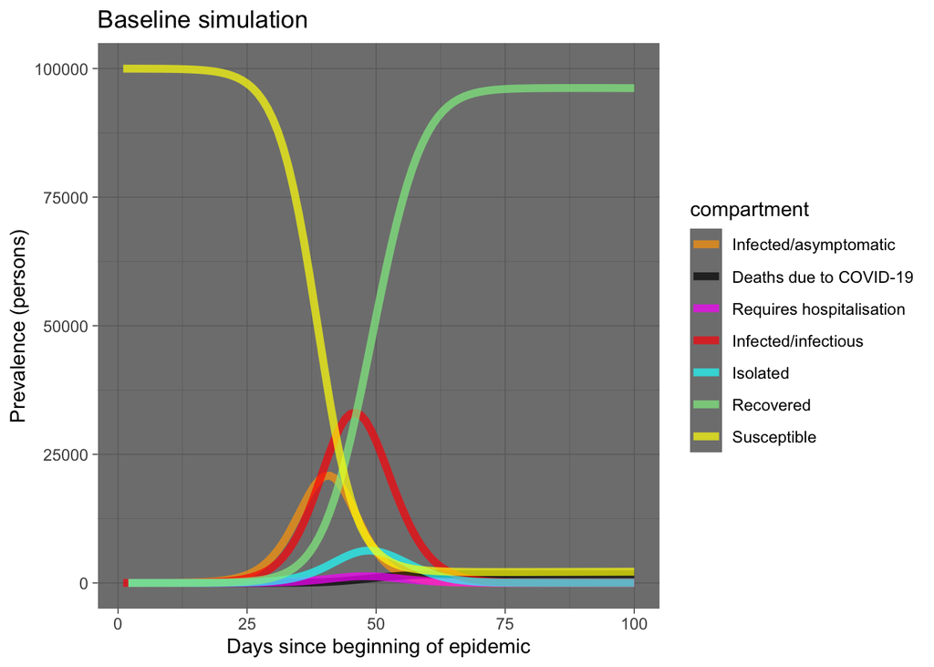

```r
baseline_plot_df <- baseline_sim$df %>% # use only the prevalence columns
select(time, s.num, e.num, i.num, q.num, h.num, r.num, f.num) %>%
    pivot_longer(-c(time), names_to = "compartment", values_to = "count") %>%
    filter(time <= 250)

# define a standard set of colours to represent compartments
compcols <- c(s.num = "yellow", e.num = "orange", i.num = "red",
    q.num = "cyan", h.num = "magenta", r.num = "lightgreen",
    f.num = "black")
complabels <- c(s.num = "Susceptible", e.num = "Infected/asymptomatic",
    i.num = "Infected/infectious", q.num = "Isolated", h.num = "Requires hospitalisation",
    r.num = "Recovered", f.num = "Deaths due to COVID-19")

baseline_plot_df %>% # examine only the first 100 days since it is all over by
# then using the default parameters
filter(time <= 100) %>% ggplot(aes(x = time, y = count, colour = compartment)) +
    geom_line(size = 2, alpha = 0.7) + scale_colour_manual(values = compcols,
    labels = complabels) + theme_dark() + labs(title = "Baseline simulation",
    x = "Days since beginning of epidemic", y = "Prevalence (persons)")
```

OK, that looks very reasonable. Note that almost the entire population ends up being infected. However, the **S** and **R** compartments dominate the plot (which is good, because it means humanity will survive!), so let’s re-plot leaving out those compartments so we can see a bit more detail.

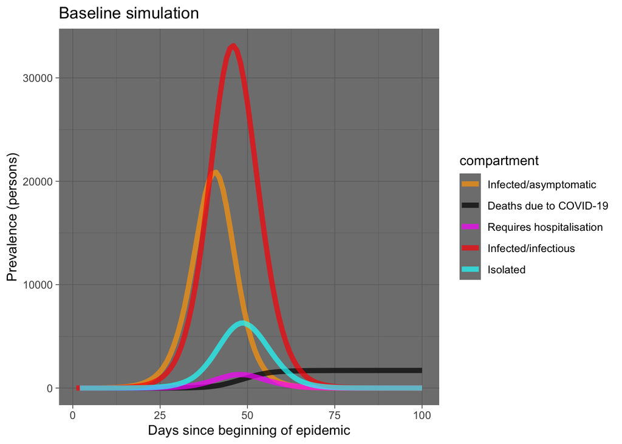

```r
baseline_plot_df %>% filter(compartment %in% c("e.num", "i.num",
    "q.num", "h.num", "f.num")) %>% filter(time <= 100) %>% ggplot(aes(x = time,
    y = count, colour = compartment)) + geom_line(size = 2, alpha = 0.7) +
    scale_colour_manual(values = compcols, labels = complabels) +
    theme_dark() + labs(title = "Baseline simulation", x = "Days since beginning of epidemic",
    y = "Prevalence (persons)")
```

Notice that the **I** compartment curve lags behind the **E** compartment curve – the lag is the incubation period, and that the **Q** curve lags still further as infected people only reluctantly and belatedly self-isolate themselves (in this baseline scenario).

## Running intervention experiments

### Scenario 1

Ramp up self-isolation rate, starting at day 1, ramp up to 0.3333, over 15 day period, then ongoing.

```r
isolation_ramp <- function(t) {
    ifelse(t <= 2, 0.0333, ifelse(t <= 17, 0.0333 + (t - 3) *
        (0.3333 - 0.03333)/15, 0.3333))
}

exp1_isolation_ramp_sim <- simulate(quar.rate = isolation_ramp(1:366))
```

### Scenario 2

Ramp up self-isolation rate, starting at day 1, ramp up to 0.6666, over 15 day period, then ongoing.

```r
big_isolation_ramp <- function(t) {
    ifelse(t <= 2, 0.0333, ifelse(t <= 17, 0.0333 + (t - 3) *
        (0.6666 - 0.03333)/15, 0.6666))
}

exp2_big_isolation_ramp_sim <- simulate(quar.rate = big_isolation_ramp(1:366))
```

### Scenario 3

As per scenario 1 plus a moderate increase in social distancing to 5 for everyone (halving the `act.rate`), again ramping it down between days 15 and 30, then maintain at 5 for a further 45 days, then revert to 10.

```r
social_distance_ramp <- function(t) {
    ifelse(t <= 17, 10, ifelse(t <= 32, 10 - (t - 17) * (10 -
        5)/15, ifelse(t <= 77, 5, 10)))
}

exp3_soc_dist_ramp_sim <- simulate(act.rate.i = social_distance_ramp(1:366),
    act.rate.e = social_distance_ramp(1:366), quar.rate = isolation_ramp(1:366))
```

### Scenario 4

As per scenario 3 but four week lockdown starting at day 30.

```r
fourweek_lockdown_day30_vector <- c(rep(10, 32), rep(2.5, 30),
    rep(10, 304))

exp4_fourweek_lockdown_day30_sim <- simulate(act.rate.i = fourweek_lockdown_day30_vector,
    act.rate.e = fourweek_lockdown_day30_vector, quar.rate = isolation_ramp(1:366))
```

### Scenario 5

As per scenario 4 but eight week lockdown starting at day 30.

```r
eightweek_lockdown_day30_vector <- c(rep(10, 32), rep(2.5, 60),
    rep(10, 274))

exp5_eightweek_lockdown_day30_sim <- simulate(act.rate.i = eightweek_lockdown_day30_vector,
    act.rate.e = eightweek_lockdown_day30_vector, quar.rate = isolation_ramp(1:366))
```

### Scenario 6

As per scenario 4 but eight week lockdown starting at day 30, followed by self-isolation with high compliance (66% per day) on an ongoing basis.

```r
post_lockdown_isolation_ramp <- function(t) {
    ifelse(t <= 2, 0.0333, ifelse(t <= 17, 0.0333 + (t - 3) *
        (0.3333 - 0.03333)/15, ifelse(t <= 92, 0.3333, 0.6666)))
}

exp6_eightweek_lockdown_day30_then_big_isol_sim <- simulate(act.rate.i = eightweek_lockdown_day30_vector,
    act.rate.e = eightweek_lockdown_day30_vector, quar.rate = post_lockdown_isolation_ramp(1:366))
```

# Results

Now let’s examine the results.

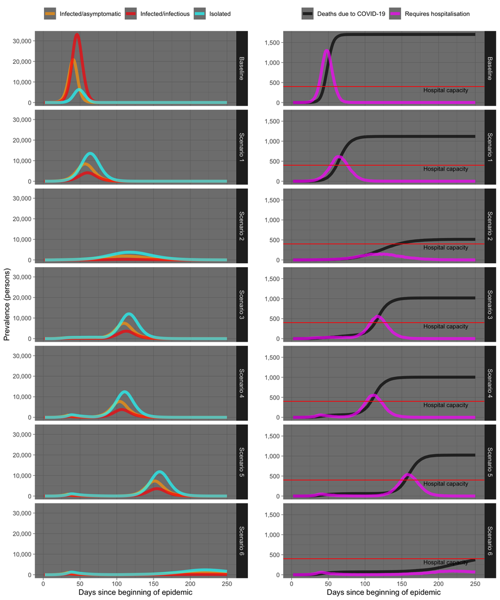

```
## 2855.813 sec elapsed
```

```r
elongate <- function(sim) {

    sim_df <- sim$df %>% # use only the prevalence columns
    select(time, s.num, e.num, i.num, q.num, h.num, r.num, f.num) %>%
        # examine only the first 100 days since it is all over by
    # then using the default parameters
    filter(time <= 250) %>% pivot_longer(-c(time), names_to = "compartment",
        values_to = "count")
    return(sim_df)
}

exp1_isolation_ramp_sim_df <- elongate(exp1_isolation_ramp_sim)
exp2_big_isolation_ramp_sim_df <- elongate(exp2_big_isolation_ramp_sim)
exp3_soc_dist_ramp_sim_df <- elongate(exp3_soc_dist_ramp_sim)
exp4_fourweek_lockdown_day30_sim_df <- elongate(exp4_fourweek_lockdown_day30_sim)
exp5_eightweek_lockdown_day30_sim_df <- elongate(exp5_eightweek_lockdown_day30_sim)
exp6_eightweek_lockdown_day30_then_big_isol_sim_df <- elongate(exp6_eightweek_lockdown_day30_then_big_isol_sim)

combined_plot_df <- baseline_plot_df %>% mutate(experiment = "Baseline") %>%
    bind_rows(exp1_isolation_ramp_sim_df %>% mutate(experiment = "Scenario 1")) %>%
    bind_rows(exp2_big_isolation_ramp_sim_df %>% mutate(experiment = "Scenario 2")) %>%
    bind_rows(exp3_soc_dist_ramp_sim_df %>% mutate(experiment = "Scenario 3")) %>%
    bind_rows(exp4_fourweek_lockdown_day30_sim_df %>% mutate(experiment = "Scenario 4")) %>%
    bind_rows(exp5_eightweek_lockdown_day30_sim_df %>% mutate(experiment = "Scenario 5")) %>%
    bind_rows(exp6_eightweek_lockdown_day30_then_big_isol_sim_df %>%
        mutate(experiment = "Scenario 6"))

p1 <- combined_plot_df %>% filter(compartment %in% c("e.num",
    "i.num", "q.num")) %>% ggplot(aes(x = time, y = count, colour = compartment)) +
    geom_line(size = 2, alpha = 0.7) + facet_grid(experiment ~
    .) + scale_colour_manual(values = compcols, labels = complabels) +
    scale_y_continuous(labels = scales::comma) + theme_dark() +
    theme(legend.title = element_blank(), legend.position = "top",
        legend.direction = "horizontal") + labs(x = "Days since beginning of epidemic",
    y = "Prevalence (persons)")

p2 <- combined_plot_df %>% filter(compartment %in% c("h.num",
    "f.num")) %>% ggplot(aes(x = time, y = count, colour = compartment)) +
    geom_line(size = 2, alpha = 0.7) + geom_hline(yintercept = hc_scaler *
    40, colour = "red") + annotate("text", x = 210, y = hc_scaler *
    (40 - 8.5), label = "Hospital capacity", size = 3) + facet_grid(experiment ~
    .) + scale_colour_manual(values = compcols, labels = complabels) +
    scale_y_continuous(labels = scales::comma) + labs(x = "Days since beginning of epidemic",
    y = "") + theme_dark() + theme(legend.title = element_blank(),
    legend.position = "top", legend.direction = "horizontal")

p1 + p2
```